# Programação em R (Nível Básico)

03 março, 2021

## Retornando a afirmação de John Chambers

- **Princípio do Objeto**: Tudo que existe em `R` é um objeto
- Definimos um objeto como uma entidade no ambiente `R` com características internas contendo informações necessárias para interpretar sua estrutura e conteúdo
  - Atributos
  - Atributos intrínsecos: **modo** e **comprimento**

## Associando o nome a um objeto

```r
> x <- 10
```

- Comandos de atribuição
- Use: `<-`, isto é, `<` + `-`
- Evite: `=`, use apenas para definir argumentos em uma função
- Nomes sintáticos e nomes não sintáticos:

## Nomes sintáticos e não sintáticos

- Deve consistir em letras, dígitos, `.` e `_`;
- Os nomes devem ser iniciado por uma letra ou um ponto não seguido de um número, isto é, Ex.: `.123`, `1n`, dentre outros;
- As letras maiúsculas se distinguem das letras minúsculas;
- Não pode inicia por `_` ou dígito, é retornado um erro no console caso isso ocorra;
- Não pode usar qualquer uma das palavras reservadas pela linguagem, isto é, `TRUE`, `FALSE`, `if`, `for`, dentre outras, que pode ser consultado usando o comando `?Reserved()`.

## Nomes sintáticos e não sintáticos

```r
# Nome nao sintatico
.123 <- 50
## Error in 0.123 <- 50 : lado esquerdo da atribuicao inválida (do_set)

# Qual a sugestao de nome sintatico para '.123'?
make.names(.123)
[1] "X0.123"
```

## Associando um nome ao objeto

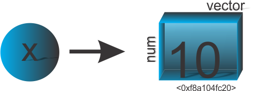

```r
> x <- 10 # Ou 10 -> x
```

```r
> lobstr::obj_addr(x)
> # [1] "0xf8a104fc20"
```

## Associando um nome ao objeto

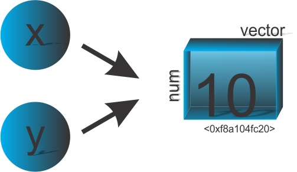

```r
> y <- x
> lobstr::obj_addr(y)
> # [1] "0xf8a104fc20"
```

## Associando um nome ao objeto e ambiente global

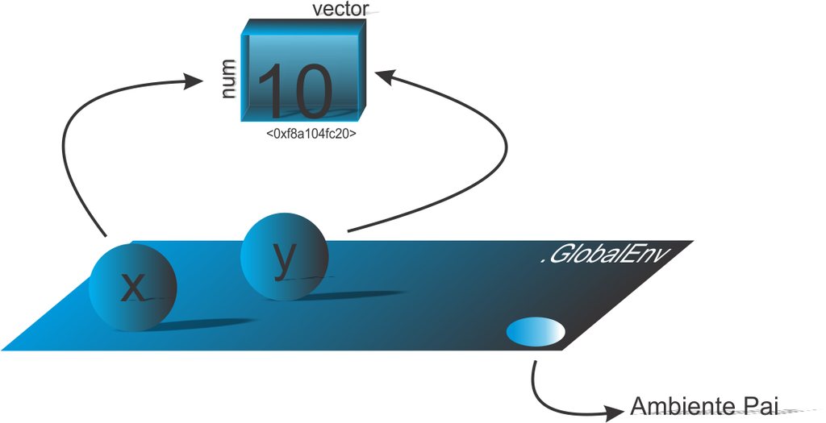

## Associando um nome ao objeto

```r
> lobstr::obj_addr(x)
> # [1] "0xf8a104fc20"
> x <- 30
> lobstr::obj_addr(x)
> # [1] "0x42db6dbb50"
```

## Atributos e Classes

- atributos intrínsecos:
  - **modo**:
    - `mode()` baseado na linguagem `S` e
    - `typeof()` baseado na linguagem `C`
  - **comprimento**: `length()`
- Demais atributos: `attributes()`
- Classe: `class()` e `sloop::s3_class()` e atributo classe por `attributes()`

## Atributo intrínseco de modo (Vetores)

```r
> # Objeto modo caractere
> x <- "Ben"; mode(x)
```

```
## [1] "character"
```

```r
> # Objeto modo logico
> z <- TRUE; mode(z)
```

```
## [1] "logical"
```

```r
> # Objeto modo complexo
> w <- 1i; mode(w)
```

```
## [1] "complex"
```

## Atributo intrínseco de modo (Vetores)

```r
> # Objeto modo numerico
> y <- 10L; mode(y); y2 <- 10; mode(y2)
```

```
## [1] "numeric"
```

```
## [1] "numeric"
```

```r
> # y eh igual a y2? # y eh identico y2?
> y == y2; identical(y, y2)
```

```
## [1] TRUE
```

```
## [1] FALSE
```

## Atributo intrínseco de modo (Vetores)

```r
> # Objeto modo caractere
> x <- "Ben"; typeof(x)
```

```
## [1] "character"
```

```r
> # Objeto modo logico
> z <- TRUE; typeof(z)
```

```
## [1] "logical"
```

```r
> # Objeto modo complexo
> w <- 1i; typeof(w)
```

```
## [1] "complex"
```

## Atributo intrínseco de modo (Vetores)

```r
> # Objeto modo numerico
> y <- 10L; typeof(y); y2 <- 10; typeof(y2)
```

```
## [1] "integer"
```

```
## [1] "double"
```

```r
> # y eh igual a y2? # y eh identico y2?
> y == y2; identical(y, y2)
```

```
## [1] TRUE
```

```
## [1] FALSE
```

## Resumo do modo em vetores atômicos

| `typeof` | `mode` |
| --- | --- |
| `logical` | `logical` |
| `integer` | `numeric` |
| `double` | `numeric` |
| `complex` | `complex` |
| `character` | `character` |
| `raw` | `raw` |

## Comprimento

```r
> # Vetor de comprimento 5
> v1 <- 1:5
> # Vetor de comprimento 3
> v2 <- c("Ben", "Maria", "Lana")
> # Vetor de comprimento quatro
> v3 <- c(TRUE, FALSE, TRUE, TRUE)
> # Vejamos o comprimento dos vetores
> length(v1); length(v2); length(v3)
```

```
## [1] 5
```

```
## [1] 3
```

```
## [1] 4
```

## Comprimento

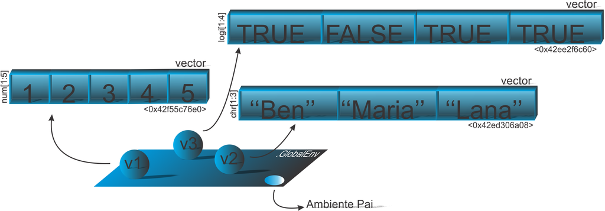

## Resumo

Um resumo as funções mensionadas podem ser refletidas com as seguintes indagações:

- `base::class()` e `loop::c3_class()`: Qual o tipo de objeto?
- `base::mode()`: Qual o tipo de dados baseados na linguagem `S`?
- `base::typeof()`: Qual o tipo de dados baseados na linguagem `C`?
- `base::attributes()`: O objeto tem atributos?
- `base::length()`: Qual o comprimento do objeto?

Sintaxe: `pacote::nome_função()`

## Classes

- Objetos que armazenam “dados,” pensando em análises:
  - `numeric`
  - `logical`
  - `character`
  - `list`
  - `matrix`
  - `array`
  - `factor`
  - `data.frame`

## Coersão do R

```r
> # Criando um objeto x e imprimindo o seu resultado
> x <- c("Nome", 3, 4, 5);x
```

```
## [1] "Nome" "3"    "4"    "5"
```

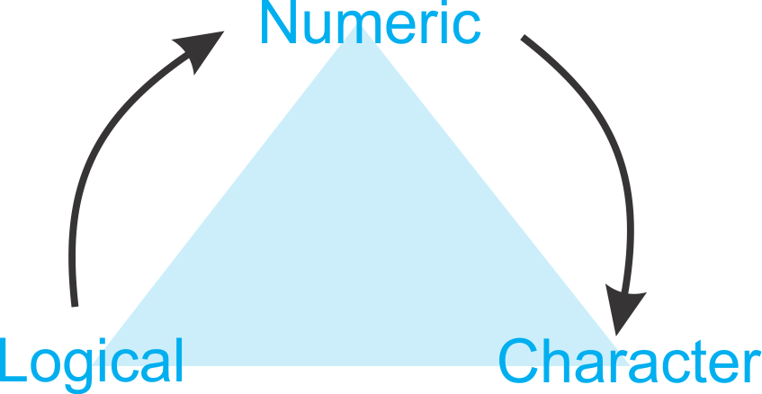

## Coersão imposta pelo usuário

```r
> # Objeto de modo numerico
> minha_idade <- 35; mode(minha_idade)
```

```
## [1] "numeric"
```

```r
> # Coersão do objeto para modo caractere (`string`)
> minha_idade <- as.character(minha_idade)
> mode(minha_idade)
```

```
## [1] "character"
```

```r
> # Verificando se o objeto tem modo 'character'
> is.character(minha_idade)
```

```
## [1] TRUE
```

## Tipo de objetos

- Vetores atômicos:
  - Lógicos, Numéricos e Caracteres;
  - Matrizes unidimensionais (*Matrix*) e multidimensionais (*Arrays*);
- Vetores em listas:
  - Listas (*Lists*);
  - Quadro de dados (*Data frames*);

Existem outros, mas para esse módulo, exploraremos estes nas seções seguintes

## Tipos de Objetos

| Objeto | Classe | Modo | São possíveis vários modos no mesmo objeto? |
| --- | --- | --- | --- |
| Vetor | `numeric` (`integer` ou `double`), `character`, `complex`, `logical`, `raw` | `numeric` (`integer` ou `double`), `character`, `complex`, `logical`, `raw` | Não |
| Matriz | `matrix` | `numeric` (`integer` ou `double`), `character`, `complex`, `logical`, `raw` | Não |

## Tipos de Objetos

| Objeto | Classe | Modo | São possíveis vários modos no mesmo objeto? |
| --- | --- | --- | --- |
| Array | `array` | `numeric` (`integer` ou `double`), `character`, `complex`, `logical`, `raw` | Não |
| lista | `list` | `numeric` (`integer` ou `double`), `character`, `complex`, `logical`, `raw`, `expression`, `function` | Sim |

## Tipos de Objetos

| Objeto | Classe | Modo | São possíveis vários modos no mesmo objeto? |
| --- | --- | --- | --- |
| Quadro de dados | `data.frame` | `numeric` (`integer` ou `double`), `character`, `complex`, `logical`, `raw` | Sim |

## Bons estudos!

[figure not shown]